# CTED Achievement Profile

Samuel Irvin

2023-08-30

# EAST VALLEY INSTITUTE OF TECHNOLOGY

[Back to CTED List](https://azcteaccountability.github.io/CTEDAchievementProfiles)

### FY 2023 - 2024 CTED Achievement Profile

| Statutorily Required Criteria | Additional Criteria |
| --- | --- |
| Graduation rate of all students enrolled in a CTE program. | Graduation rate disaggregated by population, for both CTE participants and concentrators, and disaggregated by campus type, additional comparison metrics. |
| The completion rate for each program offered by the CTED. | The program completion rate disaggregated by program and campus type, additional comparison metrics. |
| Performance on technical skills assessments. | TSA attempt and pass rates, disaggregated by program and campus type, additional comparison metrics. |
| Postgraduation employment rates, postsecondary enrollment rates, and military service rates for program completers. | Postgraduation advanced training rates, participation in a national service program rate, and placement rates disaggregated by campus type, additional comparison metrics. |
|  | Performance on industry-recognized credential assessments, including attempt and pass rates, disaggregated by program and campus type, additional comparison metrics. |

# DEFINITIONS

**CTE Participant**

A CTE participant is any student that completes and passes at least one CTE course worth at least one credit in a CTE program.

**CTE Concentrator**

A CTE concentrator is a student that completes and passes at least different two courses worth at least one credit each in a single CTE program. Internships and cooperative education are not included in determining concentrator status.

**Program Completer**

A program completer is a student that passes all the required courses in a single CTE program having earned a minimum of one credit in each required course. Internships and cooperative education courses are not included in determining program completion status.

**Technical Skills Assessment**

The Technical Skills Assessment (TSA) is a comprehensive end-of-program assessment designed to certify a student’s understanding and mastery of industry-validated knowledge and skill. TSA assessments are not credential assessments.

**Industry-recognized Credentials**

Credentials are third-party issued and industry-recognized and widely accepted certificates, licenses, and other credentials that signify a student’s mastery of industry-validated knowledge and skill. These credentials are not issued by ADE.

# CTED CAMPUSES

### CTED Central Campuses

| EVIT - East Campus |
| --- |
| EVIT - East Valley Institute of Technology |
| EVIT East Apache Junction |
| EVIT North Fountain Hills |

### Member Districts & Satellite Campuses

| **American Leadership Academy, Inc.** |
| --- |
| American Leadership Academy of Applied Technologies |
| American Leadership Academy, Anthem K-6 |
| American Leadership Academy, Gilbert North K-12 |
| American Leadership Academy, Ironwood K12 |
| American Leadership Academy, Queen Creek K-12 |
| American Leadership Academy, West Foothills K-12 |
| **Arizona Agribusiness & Equine Center, Inc. (AAEC - Mesa)** |
| AAEC - Mesa |
| **Cave Creek Unified District** |
| Cactus Shadows High School |
| **Chandler Unified District #80** |
| Arizona College Prep High School |
| Basha High School |
| Chandler High School |
| Dr. Camille Casteel High School |
| Hamilton High School |
| Perry High School |
| **Fountain Hills Unified District** |
| Fountain Hills High School |
| **Gilbert Unified District** |
| Campo Verde High School |
| Desert Ridge High |
| Gilbert High School |
| Highland High School |
| Mesquite High School |
| **Heritage Academy Gateway, Inc.** |
| Heritage Academy Gateway |
| **Higley Unified School District** |
| Higley High School |
| Williams Field High School |
| **J O Combs Unified School District** |
| Combs High School |
| **Mesa Unified District** |
| Dobson High School |
| East Valley Academy |
| Mesa High School |
| Mountain View High School |
| Red Mountain High School |
| Skyline High School |
| Westwood High School |
| **Portable Practical Educational Preparation, Inc. (PPEP, Inc.)** |
| Arizona Insight Academy |
| Arizona Virtual Academy |
| **Queen Creek Unified District** |
| Crismon High School |
| Eastmark High School |
| Queen Creek High School |
| **San Tan Montessori School, Inc.** |
| San Tan Charter School |
| **Scottsdale Unified District** |
| Arcadia High School |
| Chaparral High School |
| Coronado High School |
| Desert Mountain High School |
| Saguaro High School |
| **Tempe Union High School District** |
| Compadre High School |
| Corona Del Sol High School |
| Desert Vista High School |
| Marcos De Niza High School |
| McClintock High School |
| Mountain Pointe High School |
| Tempe High School |

All data in this profile is disaggregated by campus type and is displayed as “CTED Central Campus” or “Central + Satellite”. CTED Central campus data includes only the data reported by the campuses in the central campuses list above. Central + Satellite data includes data reported by the campuses in both the central campuses and member districts lists above. Data is deduplicated, meaning that if a student is reported by multiple entities, they are counted only once wherever possible.

# GRADUATION RATE

The graduation rate is calculated using the student’s 4-year cohort as a base. The graduation rate is calculated as the number of participants or concentrators that graduated with their cohort divided by the total number of participants or concentrators in the cohort, respectively. Graduation rate is calculated using the 2023 cohort in this Profile.

#### East Valley Institute of Technology’s Central + Satellite Campuses

##### **CTE Participants**

93.4%

##### **CTE Concentrators**

97.1%

#### East Valley Institute of Technology’s Central Campuses

##### **CTE Participants**

97.6%

##### **CTE Concentrators**

98.7%

#### Arizona

##### **All CTE and non-CTE Students in Cohort**

77.5%

### Data

| Student | Graduating | All |
| --- | --- | --- |
| **CTED Central Campus** |  |  |
| CTE Participants | 2250 | 2305 |
| CTE Concentrators | 1957 | 1982 |
| **Central + Satellite Campuses** |  |  |
| CTE Participants | 13841 | 14816 |
| CTE Concentrators | 6727 | 6929 |

### Chart

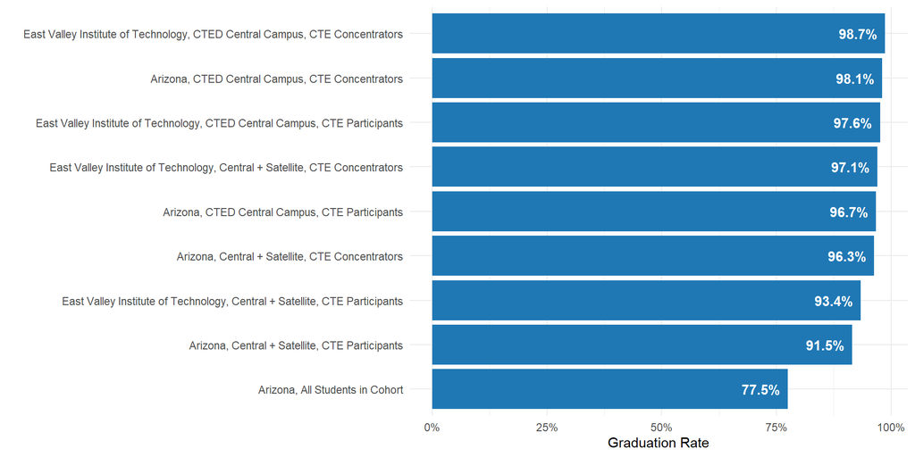

# PROGRAM COMPLETION

Empty cells in the table below indicate that the program did not have program completers at the campus type(s) specified in that column, but that campus type may have had students enrolled in the program.

#### East Valley Institute of Technology’s Central + Satellite Campuses

##### **Program Completion Rate**

40%

#### East Valley Institute of Technology’s Central Campuses

##### **Program Completion Rate**

69%

#### Arizona’s CTED Central and Satellite Campuses

##### **Program Completion Rate**

44%

#### Arizona’s CTED Central Campuses

##### **Program Completion Rate**

67.2%

### Data

| Program | Central + Satellite Program Completers | Central + Satellite Program Enrollees | Central + Satellite Program Completion Rate | CTED Central Campus Program Completers | CTED Central Campus Program Enrollees | CTED Central Campus Program Completion Rate |
| --- | --- | --- | --- | --- | --- | --- |
| Accounting | 19 | 47 | 40.4% | NA | NA | NA |
| Aesthetics | 188 | 206 | 91.3% | 183 | 199 | 92% |
| Agriscience | 155 | 1133 | 13.7% | NA | NA | NA |
| Air Transportation | 0 | 152 | 0% | 0 | 128 | 0% |
| Aircraft Mechanics | 0 | 3 | 0% | NA | NA | NA |
| Architectural Drafting | 2 | 20 | 10% | NA | NA | NA |
| Automation and Robotics | 0 | 11 | 0% | NA | NA | NA |
| Automotive Collision Repair | 0 | 15 | 0% | 0 | 15 | 0% |
| Automotive Technologies | 92 | 1028 | 8.9% | 5 | 211 | 2.4% |
| Baking and Pastry Arts | 29 | 30 | 96.7% | 29 | 30 | 96.7% |
| Barbering | 28 | 36 | 77.8% | 28 | 36 | 77.8% |
| Biomedical Sciences | 31 | 61 | 50.8% | NA | NA | NA |
| Bioscience | 164 | 763 | 21.5% | NA | NA | NA |
| Building Maintenance/Environmental Services | 0 | 6 | 0% | NA | NA | NA |
| Business Management | 103 | 376 | 27.4% | NA | NA | NA |
| Business Operations | 22 | 359 | 6.1% | NA | NA | NA |
| Cabinetmaking | 86 | 261 | 33% | NA | NA | NA |
| Carpentry | 6 | 64 | 9.4% | NA | NA | NA |
| Construction Technologies | 107 | 267 | 40.1% | 29 | 56 | 51.8% |
| Cosmetology and Related Services | 315 | 340 | 92.6% | 314 | 336 | 93.5% |
| Culinary Arts | 850 | 3364 | 25.3% | 60 | 122 | 49.2% |
| Dental Assisting | 113 | 147 | 76.9% | 113 | 143 | 79% |
| Diesel Engine Repair | 0 | 39 | 0% | 0 | 39 | 0% |
| Digital Animation | 40 | 62 | 64.5% | 36 | 42 | 85.7% |
| Digital Communication | 64 | 329 | 19.5% | NA | NA | NA |
| Digital Photography | 343 | 1938 | 17.7% | 6 | 10 | 60% |
| Early Childhood Education | 297 | 1054 | 28.2% | 27 | 41 | 65.9% |
| Education Professions | 90 | 352 | 25.6% | NA | NA | NA |
| Electrical and Power Transmission Installation | 26 | 31 | 83.9% | 26 | 31 | 83.9% |
| Emergency Medical Services | 34 | 58 | 58.6% | 32 | 50 | 64% |
| Engineering | 170 | 1075 | 15.8% | 2 | 51 | 3.9% |
| Fashion Design and Merchandising | 62 | 161 | 38.5% | 23 | 32 | 71.9% |
| Film and TV Production | 298 | 1188 | 25.1% | 19 | 22 | 86.4% |
| Finance | 135 | 431 | 31.3% | NA | NA | NA |
| Fire Service | 67 | 77 | 87% | 67 | 77 | 87% |
| Graphic Design | 278 | 1214 | 22.9% | 33 | 53 | 62.3% |
| Heating, Ventilation and Air Conditioning | 10 | 15 | 66.7% | 10 | 15 | 66.7% |
| Home Health Aide | 11 | 49 | 22.4% | NA | NA | NA |
| Hospitality Management | 17 | 46 | 37% | 2 | 2 | 100% |
| Interior Design | 49 | 111 | 44.1% | 32 | 38 | 84.2% |
| JROTC Air Force/Spaceforce | 0 | 24 | 0% | NA | NA | NA |
| Law and Public Safety | 269 | 814 | 33% | 78 | 85 | 91.8% |
| Marketing | 517 | 1955 | 26.4% | NA | NA | NA |
| Medical Assisting Services | 215 | 324 | 66.4% | 204 | 272 | 75% |
| Mental and Social Health Technician | 47 | 50 | 94% | 47 | 49 | 95.9% |
| Music and Audio Production | 43 | 65 | 66.2% | 33 | 37 | 89.2% |
| Network Security | 73 | 198 | 36.9% | 26 | 40 | 65% |
| Nursing Services | 248 | 380 | 65.3% | 148 | 201 | 73.6% |
| Pharmacy Support Services | 28 | 63 | 44.4% | 28 | 32 | 87.5% |
| Physical Therapy Assistant | 37 | 54 | 68.5% | 37 | 54 | 68.5% |
| Plumbing | 11 | 13 | 84.6% | 11 | 13 | 84.6% |
| Precision Machining | 0 | 9 | 0% | 0 | 5 | 0% |
| Software and App Design | 322 | 1258 | 25.6% | 46 | 52 | 88.5% |
| Sports Medicine and Rehabilitation | 575 | 2074 | 27.7% | NA | NA | NA |
| Stagecraft | 144 | 448 | 32.1% | NA | NA | NA |
| Technology Devices Maintenance | 63 | 280 | 22.5% | 17 | 21 | 81% |
| Therapeutic Massage | 15 | 16 | 93.8% | 15 | 16 | 93.8% |
| Veterinary Assisting | 87 | 162 | 53.7% | 87 | 135 | 64.4% |
| Welding Technologies | 315 | 628 | 50.2% | 153 | 207 | 73.9% |

### Chart

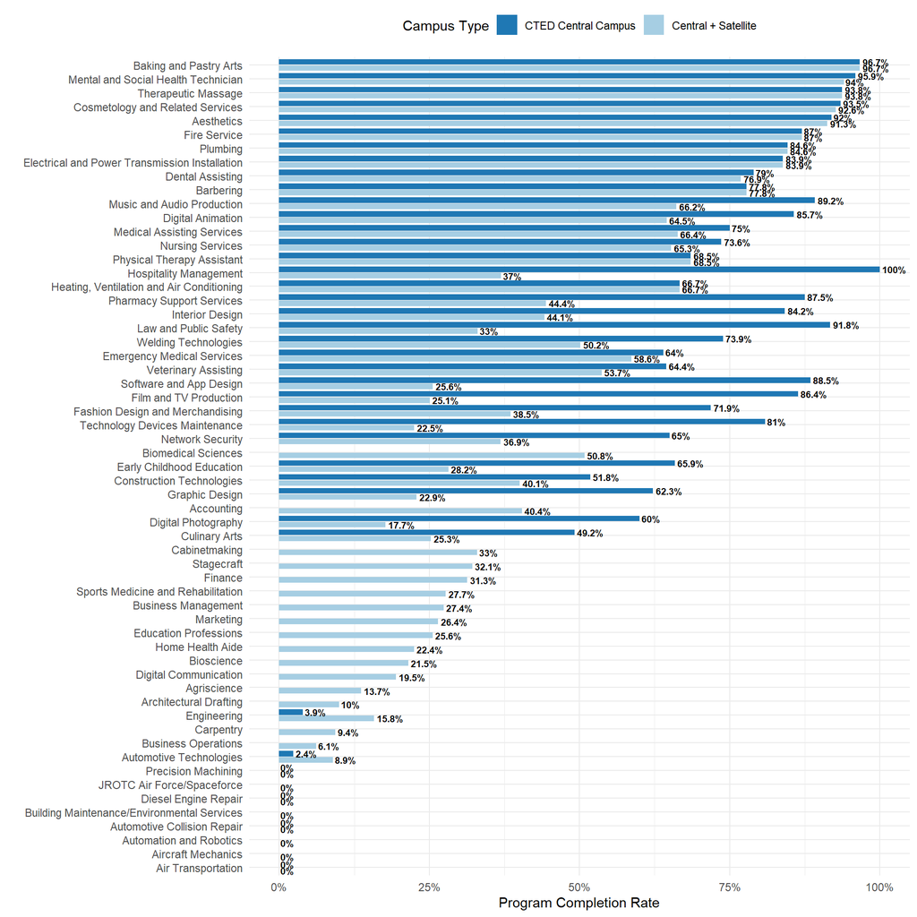

### Alternative Method

An alternative method to calculating program completion rate is to divide the number of program completers by the number of students that completed/passed at least the first course in the program. This method discounts any student that did not pass at least the first course of a program, but more accurately portrays program completion and retention among students that are attempting to complete the program.

| Program | Campus Type | Program Completers | Program Enrollees | Program Completion Rate |
| --- | --- | --- | --- | --- |
| All Programs | Central + Satellite | 6806 | 15483 | 44% |
| All Programs | CTED Central Campus | 1955 | 2750 | 71.1% |
| Accounting | Central + Satellite | 19 | 46 | 41.3% |
| Aesthetics | Central + Satellite | 188 | 206 | 91.3% |
| Aesthetics | CTED Central Campus | 183 | 199 | 92% |
| Agriscience | Central + Satellite | 155 | 970 | 16% |
| Air Transportation | Central + Satellite | 0 | 145 | 0% |
| Air Transportation | CTED Central Campus | 0 | 125 | 0% |
| Aircraft Mechanics | Central + Satellite | 0 | 3 | 0% |
| Architectural Drafting | Central + Satellite | 2 | 14 | 14.3% |
| Automation and Robotics | Central + Satellite | 0 | 10 | 0% |
| Automotive Collision Repair | Central + Satellite | 0 | 15 | 0% |
| Automotive Collision Repair | CTED Central Campus | 0 | 15 | 0% |
| Automotive Technologies | Central + Satellite | 92 | 903 | 10.2% |
| Automotive Technologies | CTED Central Campus | 5 | 205 | 2.4% |
| Baking and Pastry Arts | Central + Satellite | 29 | 30 | 96.7% |
| Baking and Pastry Arts | CTED Central Campus | 29 | 30 | 96.7% |
| Barbering | Central + Satellite | 28 | 36 | 77.8% |
| Barbering | CTED Central Campus | 28 | 36 | 77.8% |
| Biomedical Sciences | Central + Satellite | 31 | 54 | 57.4% |
| Bioscience | Central + Satellite | 164 | 712 | 23% |
| Building Maintenance/Environmental Services | Central + Satellite | 0 | 4 | 0% |
| Business Management | Central + Satellite | 103 | 314 | 32.8% |
| Business Operations | Central + Satellite | 22 | 293 | 7.5% |
| Cabinetmaking | Central + Satellite | 86 | 225 | 38.2% |
| Carpentry | Central + Satellite | 6 | 41 | 14.6% |
| Construction Technologies | Central + Satellite | 107 | 237 | 45.1% |
| Construction Technologies | CTED Central Campus | 29 | 47 | 61.7% |
| Cosmetology and Related Services | Central + Satellite | 315 | 340 | 92.6% |
| Cosmetology and Related Services | CTED Central Campus | 314 | 336 | 93.5% |

[output cut: 70 more lines]

# TECHNICAL SKILLS ASSESSMENT

The CTE technical skills assessment, or TSA, is a comprehensive end-of-program assessment designed to certify a student’s understanding and mastery of industry-validated knowledge and skill. TSA assessments are not credential assessments, but rather students are issued a certificate of passing by the Arizona Department of Education and endorsed by the Arizona CTE Quality Commission.

#### Technical Skills Assessment Pass Rates

TSA pass rates are calculated as the number of students in the reporting year cohort that attempted the TSA for their CTE program and passed it divided by the number of students in the same cohort that attempted the TSA for their program. TSA pass rates include all students who attempt the TSA regardless of CTE concentrators status.

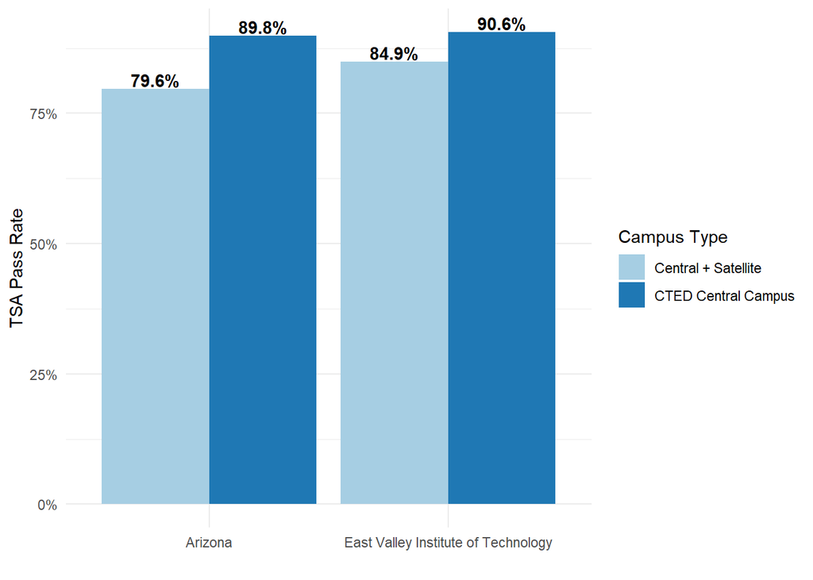

#### Technical Skills Assessment Attempt Rates

The attempt rate for technical skills assessment is calculated as the number of CTE concentrators in the reporting year cohort who attempt the TSA for their program divided by the total number of CTE concentrators in the cohort. Attempt rate is calculated using CTE concentrators rather than all students as students are typically expected to attempt the TSA after becoming a CTE concentrator.

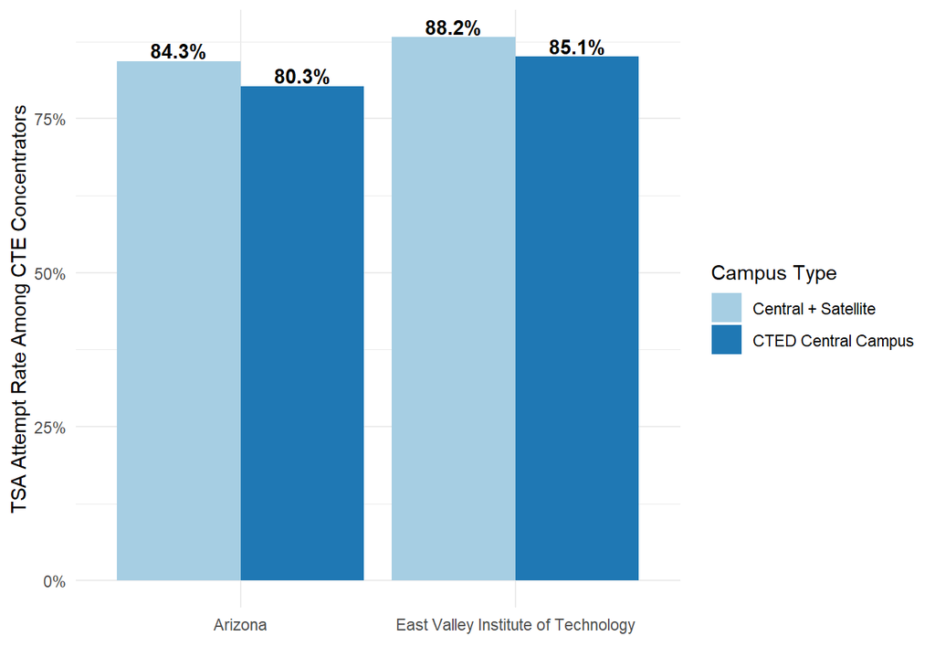

#### TSA Pass and Attempt Rates by Program

### Pass Rates

TSA pass rates are calculated as the number of students in the reporting year cohort that attempted the TSA for their CTE program and passed it divided by the number of students in the same cohort that attempted the TSA for their program.

| Campus Type | Program Name | Number of Cohort Students that Passed the TSA | Number of Cohort Students that Took the TSA | TSA Pass Rate |
| --- | --- | --- | --- | --- |
| Central + Satellite | Accounting | 17 | 23 | 73.9% |
| Central + Satellite | Agriscience | 185 | 252 | 73.4% |
| Central + Satellite | Air Transportation | 86 | 110 | 78.2% |
| CTED Central Campus | Air Transportation | 86 | 110 | 78.2% |
| Central + Satellite | Architectural Drafting | 1 | 1 | 100% |
| Central + Satellite | Automotive Collision Repair | 14 | 14 | 100% |
| CTED Central Campus | Automotive Collision Repair | 14 | 14 | 100% |
| Central + Satellite | Automotive Technologies | 209 | 336 | 62.2% |
| CTED Central Campus | Automotive Technologies | 140 | 177 | 79.1% |
| Central + Satellite | Bioscience | 145 | 174 | 83.3% |
| Central + Satellite | Business Management | 91 | 119 | 76.5% |
| Central + Satellite | Business Operations | 23 | 26 | 88.5% |
| Central + Satellite | Cabinetmaking | 46 | 82 | 56.1% |
| Central + Satellite | Carpentry | 5 | 10 | 50% |
| Central + Satellite | Construction Technologies | 61 | 118 | 51.7% |
| CTED Central Campus | Construction Technologies | 21 | 34 | 61.8% |
| Central + Satellite | Cosmetology and Related Services | 274 | 305 | 89.8% |
| CTED Central Campus | Cosmetology and Related Services | 274 | 305 | 89.8% |
| Central + Satellite | Culinary Arts | 734 | 887 | 82.8% |
| CTED Central Campus | Culinary Arts | 62 | 67 | 92.5% |
| Central + Satellite | Dental Assisting | 102 | 117 | 87.2% |
| CTED Central Campus | Dental Assisting | 102 | 117 | 87.2% |
| Central + Satellite | Diesel Engine Repair | 13 | 29 | 44.8% |
| CTED Central Campus | Diesel Engine Repair | 13 | 29 | 44.8% |
| Central + Satellite | Digital Animation | 41 | 43 | 95.3% |
| CTED Central Campus | Digital Animation | 39 | 39 | 100% |
| Central + Satellite | Digital Communication | 46 | 63 | 73% |
| Central + Satellite | Digital Photography | 265 | 363 | 73% |
| CTED Central Campus | Digital Photography | 7 | 7 | 100% |
| Central + Satellite | Early Childhood Education | 295 | 305 | 96.7% |
| CTED Central Campus | Early Childhood Education | 31 | 31 | 100% |
| Central + Satellite | Education Professions | 77 | 88 | 87.5% |
| Central + Satellite | Emergency Medical Services | 35 | 35 | 100% |
| CTED Central Campus | Emergency Medical Services | 34 | 34 | 100% |
| Central + Satellite | Engineering | 254 | 265 | 95.8% |
| CTED Central Campus | Engineering | 42 | 44 | 95.5% |
| Central + Satellite | Fashion Design and Merchandising | 61 | 71 | 85.9% |
| CTED Central Campus | Fashion Design and Merchandising | 26 | 27 | 96.3% |
| Central + Satellite | Film and TV Production | 288 | 302 | 95.4% |
| CTED Central Campus | Film and TV Production | 21 | 21 | 100% |
| Central + Satellite | Finance | 142 | 152 | 93.4% |
| Central + Satellite | Fire Service | 68 | 72 | 94.4% |
| CTED Central Campus | Fire Service | 68 | 72 | 94.4% |
| Central + Satellite | Graphic Design | 271 | 292 | 92.8% |
| CTED Central Campus | Graphic Design | 36 | 36 | 100% |
| Central + Satellite | Home Health Aide | 9 | 11 | 81.8% |
| Central + Satellite | Hospitality Management | 12 | 17 | 70.6% |
| CTED Central Campus | Hospitality Management | 2 | 2 | 100% |
| Central + Satellite | Interior Design | 45 | 55 | 81.8% |
| CTED Central Campus | Interior Design | 33 | 36 | 91.7% |
| Central + Satellite | Law and Public Safety | 260 | 280 | 92.9% |
| CTED Central Campus | Law and Public Safety | 79 | 81 | 97.5% |
| Central + Satellite | Marketing | 458 | 537 | 85.3% |
| Central + Satellite | Medical Assisting Services | 207 | 210 | 98.6% |
| CTED Central Campus | Medical Assisting Services | 199 | 202 | 98.5% |
| Central + Satellite | Mental and Social Health Technician | 46 | 47 | 97.9% |
| CTED Central Campus | Mental and Social Health Technician | 46 | 47 | 97.9% |
| Central + Satellite | Music and Audio Production | 40 | 47 | 85.1% |
| CTED Central Campus | Music and Audio Production | 30 | 35 | 85.7% |
| Central + Satellite | Network Security | 62 | 79 | 78.5% |
| CTED Central Campus | Network Security | 26 | 29 | 89.7% |
| Central + Satellite | Nursing Services | 253 | 255 | 99.2% |
| CTED Central Campus | Nursing Services | 150 | 150 | 100% |
| Central + Satellite | Pharmacy Support Services | 29 | 30 | 96.7% |
| CTED Central Campus | Pharmacy Support Services | 29 | 30 | 96.7% |
| Central + Satellite | Precision Machining | 4 | 5 | 80% |
| CTED Central Campus | Precision Machining | 4 | 5 | 80% |
| Central + Satellite | Software and App Design | 290 | 353 | 82.2% |
| CTED Central Campus | Software and App Design | 42 | 47 | 89.4% |
| Central + Satellite | Sports Medicine and Rehabilitation | 487 | 590 | 82.5% |
| Central + Satellite | Stagecraft | 120 | 152 | 78.9% |
| Central + Satellite | Technology Devices Maintenance | 39 | 61 | 63.9% |
| CTED Central Campus | Technology Devices Maintenance | 18 | 18 | 100% |
| Central + Satellite | Therapeutic Massage | 12 | 15 | 80% |
| CTED Central Campus | Therapeutic Massage | 12 | 15 | 80% |
| Central + Satellite | Veterinary Assisting | 90 | 90 | 100% |
| CTED Central Campus | Veterinary Assisting | 90 | 90 | 100% |
| Central + Satellite | Welding Technologies | 261 | 333 | 78.4% |
| CTED Central Campus | Welding Technologies | 152 | 179 | 84.9% |

### Attempt Rates

Attempt rate is calculated using CTE concentrators rather than all students as students are typically expected to attempt the TSA after becoming a CTE concentrator.

| Campus Type | Program Name | Number of Concentrators that Took the TSA | Number of Concentrators in the Cohort | TSA Attempt Rate Among CTE Concentrators |
| --- | --- | --- | --- | --- |
| Central + Satellite | Accounting | 23 | 23 | 100% |
| Central + Satellite | Agriscience | 219 | 377 | 58.1% |
| Central + Satellite | Air Transportation | 108 | 114 | 94.7% |
| CTED Central Campus | Air Transportation | 108 | 112 | 96.4% |
| Central + Satellite | Architectural Drafting | 1 | 2 | 50% |
| Central + Satellite | Automotive Collision Repair | 14 | 14 | 100% |
| CTED Central Campus | Automotive Collision Repair | 14 | 14 | 100% |
| Central + Satellite | Automotive Technologies | 325 | 455 | 71.4% |
| CTED Central Campus | Automotive Technologies | 171 | 179 | 95.5% |
| Central + Satellite | Bioscience | 148 | 164 | 90.2% |
| Central + Satellite | Business Management | 102 | 104 | 98.1% |
| Central + Satellite | Business Operations | 22 | 22 | 100% |
| Central + Satellite | Cabinetmaking | 82 | 86 | 95.3% |
| Central + Satellite | Carpentry | 6 | 6 | 100% |
| Central + Satellite | Construction Technologies | 106 | 113 | 93.8% |
| CTED Central Campus | Construction Technologies | 33 | 35 | 94.3% |
| Central + Satellite | Cosmetology and Related Services | 302 | 315 | 95.9% |
| CTED Central Campus | Cosmetology and Related Services | 302 | 314 | 96.2% |
| Central + Satellite | Culinary Arts | 827 | 866 | 95.5% |
| CTED Central Campus | Culinary Arts | 65 | 65 | 100% |
| Central + Satellite | Dental Assisting | 117 | 117 | 100% |
| CTED Central Campus | Dental Assisting | 117 | 117 | 100% |
| Central + Satellite | Diesel Engine Repair | 28 | 31 | 90.3% |
| CTED Central Campus | Diesel Engine Repair | 28 | 31 | 90.3% |
| Central + Satellite | Digital Animation | 42 | 43 | 97.7% |
| CTED Central Campus | Digital Animation | 38 | 39 | 97.4% |
| Central + Satellite | Digital Communication | 56 | 67 | 83.6% |
| Central + Satellite | Digital Photography | 336 | 348 | 96.6% |
| CTED Central Campus | Digital Photography | 7 | 8 | 87.5% |
| Central + Satellite | Early Childhood Education | 292 | 307 | 95.1% |
| CTED Central Campus | Early Childhood Education | 31 | 31 | 100% |
| Central + Satellite | Education Professions | 80 | 92 | 87% |
| Central + Satellite | Emergency Medical Services | 34 | 36 | 94.4% |
| CTED Central Campus | Emergency Medical Services | 33 | 34 | 97.1% |
| Central + Satellite | Engineering | 260 | 386 | 67.4% |
| CTED Central Campus | Engineering | 43 | 47 | 91.5% |
| Central + Satellite | Fashion Design and Merchandising | 66 | 66 | 100% |
| CTED Central Campus | Fashion Design and Merchandising | 27 | 27 | 100% |
| Central + Satellite | Film and TV Production | 277 | 303 | 91.4% |
| CTED Central Campus | Film and TV Production | 20 | 20 | 100% |
| Central + Satellite | Finance | 133 | 135 | 98.5% |
| Central + Satellite | Fire Service | 72 | 72 | 100% |
| CTED Central Campus | Fire Service | 72 | 72 | 100% |
| Central + Satellite | Graphic Design | 274 | 280 | 97.9% |
| CTED Central Campus | Graphic Design | 34 | 34 | 100% |
| Central + Satellite | Home Health Aide | 10 | 11 | 90.9% |
| Central + Satellite | Hospitality Management | 17 | 17 | 100% |
| CTED Central Campus | Hospitality Management | 2 | 2 | 100% |
| Central + Satellite | Interior Design | 52 | 52 | 100% |
| CTED Central Campus | Interior Design | 35 | 35 | 100% |
| Central + Satellite | Law and Public Safety | 267 | 273 | 97.8% |
| CTED Central Campus | Law and Public Safety | 80 | 81 | 98.8% |
| Central + Satellite | Marketing | 504 | 522 | 96.6% |
| Central + Satellite | Medical Assisting Services | 210 | 219 | 95.9% |
| CTED Central Campus | Medical Assisting Services | 202 | 207 | 97.6% |
| Central + Satellite | Mental and Social Health Technician | 47 | 47 | 100% |
| CTED Central Campus | Mental and Social Health Technician | 47 | 47 | 100% |
| Central + Satellite | Music and Audio Production | 45 | 46 | 97.8% |
| CTED Central Campus | Music and Audio Production | 35 | 36 | 97.2% |
| Central + Satellite | Network Security | 77 | 79 | 97.5% |
| CTED Central Campus | Network Security | 28 | 30 | 93.3% |
| Central + Satellite | Nursing Services | 248 | 250 | 99.2% |
| CTED Central Campus | Nursing Services | 149 | 150 | 99.3% |
| Central + Satellite | Pharmacy Support Services | 29 | 29 | 100% |
| CTED Central Campus | Pharmacy Support Services | 29 | 29 | 100% |
| Central + Satellite | Precision Machining | 5 | 6 | 83.3% |
| CTED Central Campus | Precision Machining | 5 | 5 | 100% |
| Central + Satellite | Software and App Design | 312 | 331 | 94.3% |
| CTED Central Campus | Software and App Design | 47 | 48 | 97.9% |
| Central + Satellite | Sports Medicine and Rehabilitation | 551 | 577 | 95.5% |
| Central + Satellite | Stagecraft | 142 | 146 | 97.3% |
| Central + Satellite | Technology Devices Maintenance | 55 | 65 | 84.6% |
| CTED Central Campus | Technology Devices Maintenance | 18 | 18 | 100% |
| Central + Satellite | Therapeutic Massage | 15 | 15 | 100% |
| CTED Central Campus | Therapeutic Massage | 15 | 15 | 100% |
| Central + Satellite | Veterinary Assisting | 90 | 99 | 90.9% |
| CTED Central Campus | Veterinary Assisting | 90 | 97 | 92.8% |
| Central + Satellite | Welding Technologies | 315 | 339 | 92.9% |
| CTED Central Campus | Welding Technologies | 171 | 173 | 98.8% |

# POSTGRADUATION PLACEMENT

The postgraduation placement of CTE concentrators is calculated as the number of eligible CTE concentrators that have some form of placement divided by the number of eligible CTE concentrators that responded to a placement survey administered by their CTED or school district. CTE concentrators are considered eligible for a placement survey if they (1) are a CTE concentrator, and (2) left secondary education in the reporting year. There are five placement categories: enrollment in postsecondary education, enrollment in a postsecondary advanced training program, military service, participation in a national service program or the Peace Corps, or employment. The placement survey also collects “relatedness” of a student’s postgraduation placement to their high school CTE program.

#### East Valley Institute of Technology’s Central + Satellite Campuses

##### **Students Eligible for Placement**

7245

##### **Survey Respondents**

6475

##### **Students with Placement**

5378

##### **Placement Rate**

83.1%

##### **Survey Response Rate**

89.4%

#### East Valley Institute of Technology’s Central Campuses

##### **Students Eligible for Placement**

2074

##### **Survey Respondents**

2038

##### **Students with Placement**

1561

##### **Placement Rate**

76.6%

##### **Survey Response Rate**

98.3%

#### Placement rates by Category

| Category | Counts Central + Satellite | Counts CTED Central Campus | Percentages Central + Satellite | Percentages CTED Central Campus |
| --- | --- | --- | --- | --- |
| Postsecondary Education | 4232 | 1059 | 65.4% | 52% |
| Advanced Training | 132 | 108 | 2% | 5.3% |
| Military Service | 107 | 38 | 1.7% | 1.9% |
| Public Service Program | 3 | 2 | 0% | 0.1% |
| Employment | 1735 | 946 | 26.8% | 46.4% |

Note: Placement rates by category may not add up to the total placement rate as students may be placed in multiple categories.

#### Comparison to Statewide CTE Placement Rates

[figure not shown]

# INDUSTRY CREDENTIALS

Attainment of portable, industry-recognized and validated credentials, certificates, and licenses are a unique measure of CTE program success. These credentials, which are offered by third-party credentialing organizations, signal to employers that CTE students have mastered a specific set of knowledge, skills, and abilities as outlined by their CTE program.

#### East Valley Institute of Technology’s Central + Satellite Campuses

##### **Credential Pass Rate**

84.7%

#### East Valley Institute of Technology’s Central Campuses

##### **Credential Pass Rate**

91.5%

#### Arizona’s CTED Central and Satellite Campuses

##### **Credential Pass Rate**

85.8%

#### Arizona’s CTED Central Campuses

##### **Credential Pass Rate**

93.9%

#### Industry Credentials Pass and Attempt Rates

### Pass Rates

Credential pass rates are calculated as the total number of students in the cohort that earned an industry-recognized credential divided by the total number of students in the cohort that attempted to earn an industry-recognized credential.

| Program | Central + Satellite Campuses Earned Credential | Central + Satellite Campuses Attempted Credential | Central + Satellite Campuses Credential Pass Rate | CTED Central Campuses Earned Credential | CTED Central Campuses Attempted Credential | CTED Central Campuses Credential Pass Rate |
| --- | --- | --- | --- | --- | --- | --- |
| Accounting | 7 | 24 | 29.2% | NA | NA | NA |
| Aesthetics | 18 | 18 | 100% | 18 | 18 | 100% |
| Agriscience | 247 | 265 | 93.2% | NA | NA | NA |
| Air Transportation | 20 | 20 | 100% | 20 | 20 | 100% |
| Architectural Drafting | 2 | 2 | 100% | NA | NA | NA |
| Automotive Collision Repair | 10 | 10 | 100% | 10 | 10 | 100% |
| Automotive Technologies | 240 | 279 | 86% | 188 | 196 | 95.9% |
| Biomedical Sciences | 29 | 29 | 100% | NA | NA | NA |
| Bioscience | 172 | 178 | 96.6% | NA | NA | NA |
| Business Management | 77 | 101 | 76.2% | NA | NA | NA |
| Business Operations | 3 | 5 | 60% | NA | NA | NA |
| Cabinetmaking | 89 | 95 | 93.7% | NA | NA | NA |
| Carpentry | 46 | 46 | 100% | NA | NA | NA |
| Construction Technologies | 124 | 127 | 97.6% | 31 | 31 | 100% |
| Culinary Arts | 314 | 610 | 51.5% | 35 | 52 | 67.3% |
| Dental Assisting | 83 | 115 | 72.2% | 83 | 115 | 72.2% |
| Diesel Engine Repair | 24 | 31 | 77.4% | 24 | 31 | 77.4% |
| Digital Animation | 23 | 27 | 85.2% | 23 | 23 | 100% |
| Digital Communication | 7 | 24 | 29.2% | NA | NA | NA |
| Digital Photography | 148 | 218 | 67.9% | 3 | 3 | 100% |
| Early Childhood Education | 199 | 248 | 80.2% | 32 | 32 | 100% |
| Education Professions | 41 | 43 | 95.3% | NA | NA | NA |
| Electrical and Power Transmission Installation | 20 | 20 | 100% | 20 | 20 | 100% |
| Emergency Medical Services | 1 | 1 | 100% | 1 | 1 | 100% |
| Engineering | 189 | 235 | 80.4% | 5 | 5 | 100% |
| Fashion Design and Merchandising | 50 | 51 | 98% | 16 | 16 | 100% |
| Film and TV Production | 156 | 213 | 73.2% | 12 | 14 | 85.7% |
| Finance | 8 | 11 | 72.7% | NA | NA | NA |
| Fire Service | 33 | 33 | 100% | 33 | 33 | 100% |
| Graphic Design | 195 | 221 | 88.2% | 29 | 29 | 100% |
| Heating, Ventilation and Air Conditioning | 15 | 15 | 100% | 15 | 15 | 100% |
| Home Health Aide | 9 | 9 | 100% | NA | NA | NA |
| Hospitality Management | 2 | 2 | 100% | 2 | 2 | 100% |
| Interior Design | 52 | 55 | 94.5% | 36 | 36 | 100% |
| Law and Public Safety | 245 | 252 | 97.2% | 63 | 63 | 100% |
| Marketing | 426 | 476 | 89.5% | NA | NA | NA |
| Medical Assisting Services | 183 | 209 | 87.6% | 176 | 202 | 87.1% |
| Mental and Social Health Technician | 47 | 47 | 100% | 47 | 47 | 100% |
| Music and Audio Production | 22 | 23 | 95.7% | 18 | 18 | 100% |
| Network Security | 10 | 26 | 38.5% | 5 | 14 | 35.7% |
| Nursing Services | 175 | 184 | 95.1% | 111 | 112 | 99.1% |
| Pharmacy Support Services | 20 | 20 | 100% | 20 | 20 | 100% |
| Physical Therapy Assistant | 31 | 31 | 100% | 31 | 31 | 100% |
| Plumbing | 13 | 13 | 100% | 13 | 13 | 100% |
| Precision Machining | 5 | 5 | 100% | 2 | 2 | 100% |
| Software and App Design | 158 | 224 | 70.5% | 20 | 37 | 54.1% |
| Sports Medicine and Rehabilitation | 492 | 510 | 96.5% | NA | NA | NA |
| Stagecraft | 126 | 137 | 92% | NA | NA | NA |
| Technology Devices Maintenance | 19 | 24 | 79.2% | 14 | 18 | 77.8% |
| Veterinary Assisting | 88 | 89 | 98.9% | 88 | 89 | 98.9% |
| Welding Technologies | 141 | 141 | 100% | 103 | 103 | 100% |

### Attempt Rates

Attempt rates for industry-recognized credentials is calcualted as the number of CTE concentrators in the cohort that attempted to earn a credential divided by the number of CTE concentrators in the cohort. Credential attempt rates are calcualted using concentrators as students are expected to sit for a credential exam after or near program completion.

| Program | Central + Satellite Campuses Attempted Credential | Central + Satellite Campuses Concentrators in Cohort | Central + Satellite Campuses Credential Attempt Rate | CTED Central Campuses Attempted Credential | CTED Central Campuses Concentrators in Cohort | CTED Central Campuses Credential Attempt Rate |
| --- | --- | --- | --- | --- | --- | --- |
| Accounting | 23 | 23 | 100% | NA | NA | NA |
| Aesthetics | 18 | 188 | 9.6% | 18 | 183 | 9.8% |
| Agriscience | 183 | 377 | 48.5% | NA | NA | NA |
| Air Transportation | 20 | 114 | 17.5% | 20 | 112 | 17.9% |
| Architectural Drafting | 2 | 2 | 100% | NA | NA | NA |
| Automotive Collision Repair | 9 | 14 | 64.3% | 9 | 14 | 64.3% |
| Automotive Technologies | 250 | 455 | 54.9% | 169 | 179 | 94.4% |
| Biomedical Sciences | 24 | 31 | 77.4% | NA | NA | NA |
| Bioscience | 131 | 164 | 79.9% | NA | NA | NA |
| Business Management | 91 | 104 | 87.5% | NA | NA | NA |
| Business Operations | 1 | 22 | 4.5% | NA | NA | NA |
| Cabinetmaking | 66 | 86 | 76.7% | NA | NA | NA |
| Carpentry | 6 | 6 | 100% | NA | NA | NA |
| Construction Technologies | 95 | 113 | 84.1% | 28 | 35 | 80% |
| Culinary Arts | 570 | 866 | 65.8% | 50 | 65 | 76.9% |
| Dental Assisting | 115 | 117 | 98.3% | 115 | 117 | 98.3% |
| Diesel Engine Repair | 28 | 31 | 90.3% | 28 | 31 | 90.3% |
| Digital Animation | 27 | 43 | 62.8% | 23 | 39 | 59% |
| Digital Communication | 21 | 67 | 31.3% | NA | NA | NA |
| Digital Photography | 199 | 348 | 57.2% | 3 | 8 | 37.5% |
| Early Childhood Education | 232 | 307 | 75.6% | 31 | 31 | 100% |
| Education Professions | 38 | 92 | 41.3% | NA | NA | NA |
| Electrical and Power Transmission Installation | 18 | 28 | 64.3% | 18 | 28 | 64.3% |
| Emergency Medical Services | 1 | 36 | 2.8% | 1 | 34 | 2.9% |
| Engineering | 177 | 386 | 45.9% | 5 | 47 | 10.6% |
| Fashion Design and Merchandising | 49 | 66 | 74.2% | 16 | 27 | 59.3% |
| Film and TV Production | 198 | 303 | 65.3% | 13 | 20 | 65% |
| Finance | 11 | 135 | 8.1% | NA | NA | NA |
| Fire Service | 33 | 72 | 45.8% | 33 | 72 | 45.8% |
| Graphic Design | 189 | 280 | 67.5% | 27 | 34 | 79.4% |
| Heating, Ventilation and Air Conditioning | 14 | 14 | 100% | 14 | 14 | 100% |
| Home Health Aide | 7 | 11 | 63.6% | NA | NA | NA |
| Hospitality Management | 2 | 17 | 11.8% | 2 | 2 | 100% |
| Interior Design | 51 | 52 | 98.1% | 35 | 35 | 100% |
| Law and Public Safety | 238 | 273 | 87.2% | 63 | 81 | 77.8% |
| Marketing | 439 | 522 | 84.1% | NA | NA | NA |
| Medical Assisting Services | 209 | 219 | 95.4% | 202 | 207 | 97.6% |
| Mental and Social Health Technician | 47 | 47 | 100% | 47 | 47 | 100% |
| Music and Audio Production | 23 | 46 | 50% | 18 | 36 | 50% |
| Network Security | 24 | 79 | 30.4% | 12 | 30 | 40% |
| Nursing Services | 183 | 250 | 73.2% | 111 | 150 | 74% |
| Pharmacy Support Services | 19 | 29 | 65.5% | 19 | 29 | 65.5% |
| Physical Therapy Assistant | 30 | 37 | 81.1% | 30 | 37 | 81.1% |
| Plumbing | 12 | 12 | 100% | 12 | 12 | 100% |
| Precision Machining | 3 | 6 | 50% | 2 | 5 | 40% |
| Software and App Design | 206 | 331 | 62.2% | 36 | 48 | 75% |
| Sports Medicine and Rehabilitation | 406 | 577 | 70.4% | NA | NA | NA |
| Stagecraft | 103 | 146 | 70.5% | NA | NA | NA |
| Technology Devices Maintenance | 22 | 65 | 33.8% | 18 | 18 | 100% |
| Veterinary Assisting | 89 | 99 | 89.9% | 89 | 97 | 91.8% |
| Welding Technologies | 132 | 339 | 38.9% | 96 | 173 | 55.5% |

Arizona Department of Education

Career and Technical Education

www.azed.gov/cte